# APIs and Twitter

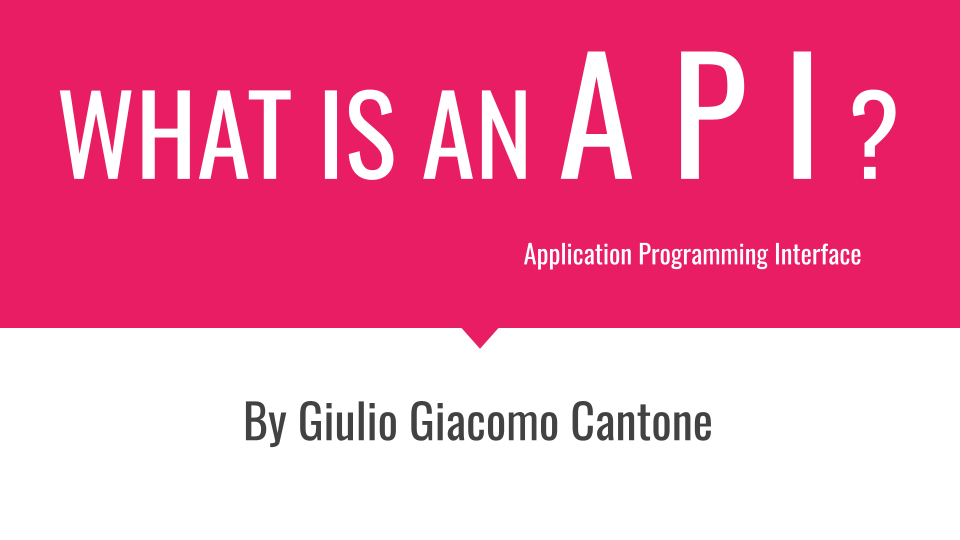

What is an API and why Computational Social Scientists use API?

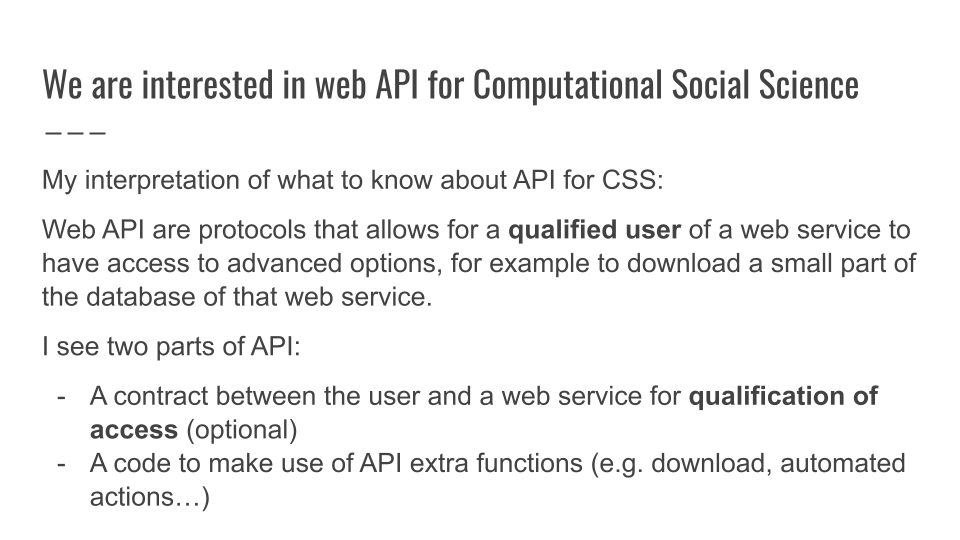

API is first and foremost a source of observational data.

### R Packages that allow to connect and download observational data

First of all, let be sure that “pacman” is installed in your library. With pacman we will install and activate some useful packages

```r
pacman::p_load("gutenbergr",
               "owidR",
               "academictwitteR")
```

[Our World in Data](https://ourworldindata.org/) is a repository for demographic and socio-economical data.

It has only few functions. The fastest way to explore all of them is to digit `owidR::` in a script or within a chunk.

The fast way to use the package `owidR` is in two steps.

- STEP 1: run the function `owid_search("")` with the “empty string” argument:

```r
owid_search("") %>% View()
```

You can than filter results with the Filter of R Studio. Once some datasets interest you, copy-paste the `chart id` value.

```r
owid("pupil-teacher-ratio-for-primary-education-by-country") -> Education
```

## Project Gutenberg is cool to download old books. Let’s look at the tible structure of these.

With this code we are going to count how many book per language are stored in [Project Gutenberg](https://www.gutenberg.org/)

```r
pacman::p_load(tidyverse)
gutenberg_metadata %>%
  group_by(language) %>%
  count()
```

| language | n |
| --- | --- |
| af | 4 |
| ale/en | 1 |
| ang/de | 1 |
| ang/en | 3 |
| ar | 1 |
| arp | 2 |
| bg | 6 |
| bgi/es | 1 |
| br | 1 |
| ca | 28 |

[output cut: 93 more lines]

The catalogue can be filtered with `tidyverse` functions.

```r
gutenberg_metadata %>%
  filter(language == "it",
         title %>% str_detect("Sicil")
         )
```

| gutenberg_id | title | author | gutenberg_author_id | language | gutenberg_bookshelf | rights | has_text |
| --- | --- | --- | --- | --- | --- | --- | --- |
| 22506 | Le tre valli della Sicilia | Sangiorgio, Gaetano | 25368 | it | IT Romanzi | Public domain in the USA. | TRUE |
| 29409 | La guerra del Vespro Siciliano vol. 1\nUn periodo delle storie Siciliane del secolo XIII | Amari, Michele | 33895 | it | IT Storia | Public domain in the USA. | TRUE |
| 30984 | Gli avvenimenti di Sicilia e le loro cause | Colajanni, Napoleone | 34935 | it | IT Scienze politiche | Public domain in the USA. | TRUE |
| 42649 | Avvenimenti faceti: Raccolti da un Anonimo Siciliano del secolo XVIII | Pitrè, Giuseppe | 39005 | it | IT Folklore | Public domain in the USA. | TRUE |
| 46887 | Storia dei musulmani di Sicilia, vol. I | Amari, Michele | 33895 | it | IT Storia | Public domain in the USA. | TRUE |
| 46888 | Storia dei musulmani di Sicilia, vol. II | Amari, Michele | 33895 | it | IT Storia | Public domain in the USA. | TRUE |
| 47114 | La guerra del Vespro Siciliano vol. 2\nUn periodo delle storie Siciliane del secolo XIII | Amari, Michele | 33895 | it | IT Storia | Public domain in the USA. | TRUE |

`gutemberg_id` is the field of values to set as argument for downloading the whole book.

```r
gutenberg_download(30984) -> Sicilia
```

Notice that this book need to be cleansed!

```r
Sicilia %>% select(text)
```

| text |
| --- |
| D.r NAPOLEONE COLAJANNI |
| _Deputato al Parlamento_ |
| GLI |
| AVVENIMENTI DI SICILIA |
| E |

[output cut: 990 more lines]

Usually books in **English** come already cleansed, in **other languages** not.